# SOC-GA 2332 Intro to Stats Lab 11

12/1/2023

## Part 0: Logistics

- Feedback to replication project part 1 released
- You have two options for part 2 (due Dec. 15)
  - A replication of the original KOB decomposition, with Table 1, 2, and Figure 2 (see instructions)
  - You can either manually code your KOB decomposition function, or use `R` packages, such as `oaxaca`. You should consider using the `twofold` rather than `threefold` option.
- Three-fold decomposition:

$$\begin{aligned}
\Delta \bar{Y} &= \bar{\boldsymbol{X}}_A'\hat{\beta}_A -
\bar{\boldsymbol{X}}_B\hat{\beta}_B \\
\Delta \bar{Y} &= \underbrace{(\bar{\boldsymbol{X}}_A -
\bar{\boldsymbol{X}}_B)'\hat{\beta}_B}_{\text{endowments}}
+ \underbrace{\bar{\boldsymbol{X}}_B'(\hat{\beta}_A -
\hat{\beta}_B)}_{\text{coefficients}} +
\underbrace{(\bar{\boldsymbol{X}}_A -
\bar{\boldsymbol{X}}_B)'(\hat{\beta}_A -
\hat{\beta}_B)}_{\text{interaction}}
\end{aligned}$$

- Two-fold decomposition:

$$\begin{aligned}
\Delta \bar{Y} &= \bar{\boldsymbol{X}}_A'\hat{\beta}_A -
\bar{\boldsymbol{X}}_B\hat{\beta}_B \\
\Delta \bar{Y} &= \underbrace{(\bar{\boldsymbol{X}}_A -
\bar{\boldsymbol{X}}_B)'\hat{\beta}_A}_{\text{explained}}
+ \underbrace{\bar{\boldsymbol{X}}_B'(\hat{\beta}_A -
\hat{\beta}_B)}_{\text{unexplained}}
\end{aligned}$$

- The second option is to extend the analysis in some meaningful way
  - For example, you may ask whether the changing racial gap or gender gap is different for people in high-earning and low-earning occupations
  - Or you may ask whether the observed pattern is true for the White-Hispanic racial gap etc.
  - Please talk to me or Siwei on the ideas you have; we can assess its feasibility
- Assignment 4 will be released tomorrow. Due date will be Dec. 20 (11:59pm)

## Part 1: Using Weights in Descriptive Statistics and Regression (for IPUMS data)

- Weights are important in deriving an unbiased estimate for the population parameter, especially when the target parameter is heterogeneous across subgroups, and some subgroups are over- or under-sampled.
- We will use the IPUMS PERWT (person weight) variable to demonstrate how to use weights for descriptive statistics and regression models.
- First, it is useful to review the PERWT variable description:
  - PERWT indicates how many persons in the U.S. population are represented by a given person in an IPUMS sample. It is generally a good idea to use PERWT when conducting a person-level analysis of any IPUMS sample. The use of PERWT is optional when analyzing one of the “flat” or unweighted IPUMS samples. Flat IPUMS samples include the 1% samples from 1850-1930, all samples from 1960, 1970, and 1980, the 1% unweighted samples from 1990 and 2000, the 10% 2010 sample, and any of the full count 100% census datasets. PERWT must be used to obtain nationally representative statistics for person-level analyses of any sample other than those.
- In `R`, there are multiple packages that can be used to generate weighted descriptive statistics such as `TAM`, `stats`, `survey` and `srvyr`. Here we use `srvyr` because it works well with `tidyverse` commands. For regression models, you can directly input the weights in the `lm()` function.

```r
## load data
wt_example <- read.csv("data/wt_example.csv")

## specify the survey design
wt_example <- wt_example %>%
  as_survey_design(weight = PERWT)

## summarization with and without weight
wt_example %>%
  summarize(unweighted.mean = mean(INCWAGE),
            unweighted.sd = sd(INCWAGE),
            weighted.mean = survey_mean(INCWAGE),
            weighted.sd = survey_sd(INCWAGE)) %>%
    kbl("html") %>%
  kable_classic_2(full_width = F)
```

| unweighted.mean | unweighted.sd | weighted.mean | weighted.mean_se | weighted.sd |
| --- | --- | --- | --- | --- |
| 24631.82 | 42187.79 | 24481.89 | 372.4915 | 41667.56 |

- How is weighted mean calculated?
- The standard error of the weighted mean is actually a non-trivial issue
  - Check out [this site](https://www.alexstephenson.me/post/2022-04-02-weighted-variance-in-r/) for some brilliant discussions
  - People also use Taylor expansion to “linearize” the ratio form of the weighted mean and get standard error. Check out the section: Variance of the weighted mean in the [page](https://en.wikipedia.org/wiki/Weighted_arithmetic_mean#cite_note-sarndal1992-3)

```r
## unweighted frequency table
wt_example %>%
  group_by(SEX) %>%
  summarize(freq = n()) %>%
  mutate(prop = freq/sum(freq)) %>%
    kbl("html") %>%
  kable_classic_2(full_width = F)
```

| SEX | freq | prop |
| --- | --- | --- |
| 1 | 8407 | 0.4853366 |
| 2 | 8915 | 0.5146634 |

```r
## weighted frequency table
wt_example %>%
  group_by(SEX) %>%
  summarize(prop = survey_prop(),
            freq = survey_total()) %>%
    kbl("html") %>%
  kable_classic_2(full_width = F)
```

| SEX | prop | prop_se | freq | freq_se |
| --- | --- | --- | --- | --- |
| 1 | 0.4961031 | 0.004637 | 120683608 | 1331502 |
| 2 | 0.5038969 | 0.004637 | 122579576 | 1267202 |

```r
## unweigthed regression
m1 <- lm(log(INCWAGE + 0.01) ~ SEX + EDUC + SEX*EDUC, data = wt_example)
## Weigthed regression
m2 <- lm(log(INCWAGE + 0.01) ~ SEX + EDUC + SEX*EDUC, data = wt_example, weights = PERWT)

## compare results
stargazer(m1, m2,
          type = "text",
          column.labels = c("Unweighted", "Weighted"),
          dep.var.labels = "Log Wage")
```

```
##
## =============================================================
##                                      Dependent variable:
##                                  ----------------------------
##                                            Log Wage
##                                    Unweighted     Weighted
##                                       (1)            (2)
## -------------------------------------------------------------
## SEX                                -2.639***      -2.680***
##                                     (0.341)        (0.334)
##
## EDUC                                0.505***      0.493***
##                                     (0.073)        (0.071)
##
## SEX:EDUC                            0.211***      0.220***
##                                     (0.046)        (0.045)
##
## Constant                            2.347***      2.675***
##                                     (0.539)        (0.526)
##
## -------------------------------------------------------------
## Observations                         17,322        17,322
## R2                                   0.075          0.077
## Adjusted R2                          0.075          0.077
## Residual Std. Error (df = 17318)     6.957         814.846
## F Statistic (df = 3; 17318)        471.312***    483.754***
## =============================================================
## Note:                             *p<0.1; **p<0.05; ***p<0.01
```

- How is the weighted coefficient calculated?

## Part 2: Missing Data

- There are many ways to deal with missing data. The “correct” strategy will depend on your data, your research question and your methods.
- But you should always be aware of the assumptions you make when inferring from a dataset with missing values

### 2.1 Complete-case analysis

- The simplest way of dealing with missing data (and what most statistical software will do automatically) is to do **complete-case** analyses. In a complete-case analysis (listwise-deletion), you retain only those observations that are non-missing for all variables in your analysis.
  - For example, the linear regression model in `R`, by default, uses complete cases
  - Pro: Simple, easy to execute
  - Con: You may lose a significant amount of data that contain important information
  - It builds upon the very strong assumption of Missing Completely At Random (MCAR)

### 2.2 Mean and Conditional Mean (Regression) Imputation

#### Mean Imputation

- Apply the mean value of each variable to all missing cases of that variable
  - Mean imputation preserves the means of variables, but it assumes a more conservative distribution of the variables and tends to weaken relationships between variables
  - Mean imputation generally yields biased regression coefficients and invalid inferences
  - It ignores the possible relation between the missing variable and other variables in imputation
  - There are no estimates of uncertainties about the imputation

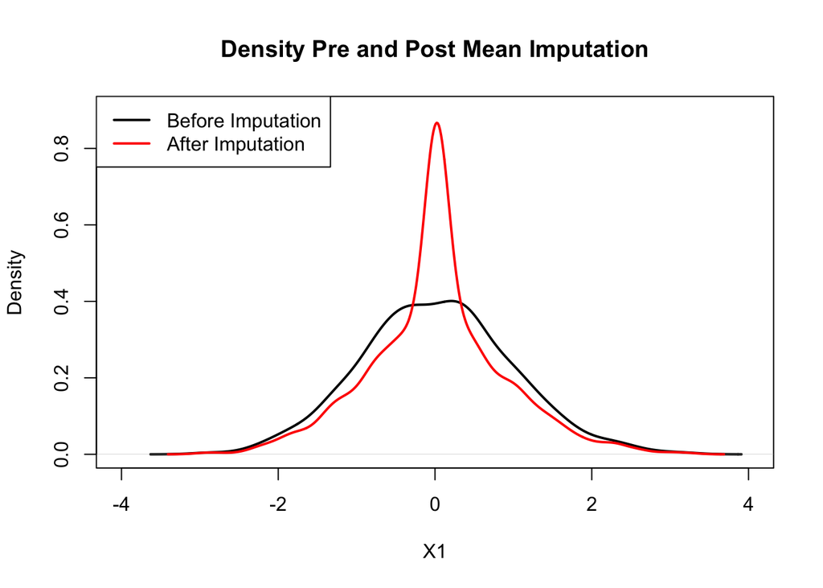

```r
## create some synthetic data with missingness
set.seed(87654)
N <- 1000

## some random variables
x1 <- round(rnorm(N), 2)
x2 <- round(x1 + rnorm(N, 10, 5))
x3 <- round(runif(N, -100, 20))

## manipulate missing values
x1[rbinom(N, 1, 0.2) == 1] <- NA  ## 20% missingness
x2[rbinom(N, 1, 0.05) == 1] <- NA ## 5% missingness
x3[rbinom(N, 1, 0.7) == 1] <- NA  ## 70% missingness

## indicator for missings (needed later)
x1_miss_ind <- is.na(x1)
x2_miss_ind <- is.na(x2)
x3_miss_ind <- is.na(x3)

## tore variables in a data frame
df_mean <- tibble(x1, x2, x3, x1_miss_ind, x2_miss_ind, x3_miss_ind)

## impute mean
df_mean <- df_mean %>%
  replace_na(list(x1 = mean(df_mean$x1, na.rm=T)))

## density of x1 pre and post imputation

### density of observed data
plot(density(df_mean$x1[x1_miss_ind == FALSE]),
     xlim = c(- 4, 4),
     ylim = c(0, 0.9),
     lwd = 2,
     main = "Density Pre and Post Mean Imputation",
     xlab = "X1")

### density of observed & imputed data
points(density(df_mean$x1),
       lwd = 2,
       type = "l",
       col = "red")

### legend
legend("topleft",
       c("Before Imputation", "After Imputation"),
       lty = 1,
       lwd = 2,
       col = c("black", "red"))
```

#### Conditional mean (regression) imputation

- Conditional-mean imputation replaces missing data with predicted values, obtained, for example, from a regression equation (regression imputation)
  - It provides the basis for Multiple Imputation, and frequently appears in the ML literature due to its “prediction” feature
  - In the simplest form, no uncertainties about imputation are introduced

### 2.3 Multiple Imputation with `mice`

```r
## load data into the environment
data(wagepan, package = "wooldridge")

## take one-year sample
dat <- wagepan %>%
  filter(year == 1980)  %>%
  select(c(agric, black, construc, ent, exper, fin, hisp,
           poorhlth, married, hours, lwage))

## save the sample
original <- dat

## remove some values to create missingness
set.seed(1234)
dat[sample(1:nrow(dat), 20), "lwage"] <- NA

## initialize code
init <- mice(dat, maxit=0)
meth <- init$method ## imputation method
predM <- init$predictorMatrix ## predictor matrix

## replace all except the variables we want to impute with ""
meth[!names(meth) == "lwage"] <- ""

## set imputation method
meth[c("lwage")] <- "norm"

## multiple imputation
set.seed(1234)
imputed_mice <- mice(dat, method = meth, predictorMatrix = predM,
               m = 5, ## by default, m = 5
               maxit = 5) ## by default, maxit = 5
## return the imputed data
imputed <- complete(imputed_mice) ## by default, the first imputed data is returned
imputed_complete <- complete(imputed_mice, "long") ## you can set `long` option to extract the complete m imputations

## check for missings
sum(is.na(imputed$lwage))
```

```
## [1] 0
```

```r
## check the predictions
actual <- original$lwage[is.na(dat$lwage)]
predicted <- imputed$lwage[is.na(dat$lwage)]
df <- tibble(actual, predicted)

## mean value
mean(actual)
```

```
## [1] 1.197811
```

```r
mean(predicted)
```

```
## [1] 1.502995
```

```r
## original and imputed
df
```

| actual | predicted |
| --- | --- |
| 1.8941150 | 1.3820382 |
| 1.7508658 | 2.2770705 |
| -0.3845819 | 1.3891130 |
| 1.4616247 | 1.3604737 |
| 0.6435003 | 1.6054285 |
| 1.4479996 | 2.0220147 |
| 1.9572239 | 2.7996889 |
| 0.9163473 | 0.8966729 |
| 1.2082853 | 1.1034097 |
| 1.1908263 | 1.9530998 |

[output cut: 10 more lines]

```r
## regression analysis with pooled imputation
fit <- with(data = imputed_mice,
            exp = lm(lwage ~ black + hisp + log(hours)))
summary(pool(fit))
```

| term | estimate | std.error | statistic | df | p.value |
| --- | --- | --- | --- | --- | --- |
| (Intercept) | -0.25218177 | 0.42451727 | -0.5940436 | 420.6886 | 5.528022e-01 |
| black | -0.07898607 | 0.07686496 | -1.0275952 | 345.5495 | 3.048590e-01 |
| hisp | -0.04695058 | 0.06637749 | -0.7073269 | 513.8068 | 4.796841e-01 |
| log(hours) | 0.22252021 | 0.05651947 | 3.9370538 | 433.4577 | 9.608194e-05 |

```r
## compare with the original regression
summary(lm(lwage ~ black + hisp + log(hours), dat))
```

```
##
## Call:
## lm(formula = lwage ~ black + hisp + log(hours), data = dat)
##
## Residuals:
##      Min       1Q   Median       3Q      Max
## -2.48846 -0.23222  0.03585  0.33587  1.67257
##
## Coefficients:
##             Estimate Std. Error t value Pr(>|t|)
## (Intercept) -0.39127    0.44524  -0.879    0.380
## black       -0.08348    0.07583  -1.101    0.271
## hisp        -0.04428    0.06774  -0.654    0.514
## log(hours)   0.24082    0.05933   4.059 5.69e-05 ***
## ---
## Signif. codes:  0 '***' 0.001 '**' 0.01 '*' 0.05 '.' 0.1 ' ' 1
##
## Residual standard error: 0.5495 on 521 degrees of freedom
##   (20 observations deleted due to missingness)
## Multiple R-squared:  0.03219,    Adjusted R-squared:  0.02662
## F-statistic: 5.777 on 3 and 521 DF,  p-value: 0.0006854
```